# R-Practice

Abhishek Bhatia PGDSMA ISI TEZPUR 2019/20 R: Intro to packages

12th September 2019

1. Use airquality dataframe to create a data frame which calculates the monthly average of Ozone, Solar.R, Wind and Temp. New dataframe will be of this form  
   Month Avg. Ozone Avg. Solar.R Avg. Wind Avg. Temp  
   May  
   June  
   July  
   August  
   September

```r
# Q1
df <- airquality
res <- aggregate(subset(df, select=-Day), by=list(df$Month),
                 FUN = mean, na.rm=T)
# Drop month column
res <- res[, -ncol(res)]

res[, "Group.1"] <- sapply(res[, "Group.1"], FUN = function (m) month.name[m])

# Change column names
colnames(res) <- c("Month", paste0("Avg.", colnames(res)[2:ncol(res)]))

res
```

| Month | Avg.Ozone | Avg.Solar.R | Avg.Wind | Avg.Temp |
| --- | --- | --- | --- | --- |
| May | 23.61538 | 181.2963 | 11.622581 | 65.54839 |
| June | 29.44444 | 190.1667 | 10.266667 | 79.10000 |
| July | 59.11538 | 216.4839 | 8.941935 | 83.90323 |
| August | 59.96154 | 171.8571 | 8.793548 | 83.96774 |
| September | 31.44828 | 167.4333 | 10.180000 | 76.90000 |

2. mtcars dataset
1. Give the names of the cars in order of decreasing mpg
2. find how many different types of cyl is there for cars having  
   mpg greater than 18
3. make a bar plot to show how many cars are there with different cyl above mpg 18
4. rank the cars (only names) in decreasing order of wt only till wt = 3

```r
# Q2
df <- mtcars

# i. Give the names of the cars in order of decreasing mpg
rownames(df[order(df$mpg, decreasing = T), ])
```

```
##  [1] "Toyota Corolla"      "Fiat 128"            "Honda Civic"
##  [4] "Lotus Europa"        "Fiat X1-9"           "Porsche 914-2"
##  [7] "Merc 240D"           "Datsun 710"          "Merc 230"
## [10] "Toyota Corona"       "Hornet 4 Drive"      "Volvo 142E"
## [13] "Mazda RX4"           "Mazda RX4 Wag"       "Ferrari Dino"
## [16] "Merc 280"            "Pontiac Firebird"    "Hornet Sportabout"
## [19] "Valiant"             "Merc 280C"           "Merc 450SL"
## [22] "Merc 450SE"          "Ford Pantera L"      "Dodge Challenger"
## [25] "Merc 450SLC"         "AMC Javelin"         "Maserati Bora"
## [28] "Chrysler Imperial"   "Duster 360"          "Camaro Z28"
## [31] "Cadillac Fleetwood"  "Lincoln Continental"
```

```r
# ii. find how many different types of cyl is there for cars having
#     mpg greater than 18

length(unique(subset(df, mpg > 18, select = cyl)$cyl))
```

```
## [1] 3
```

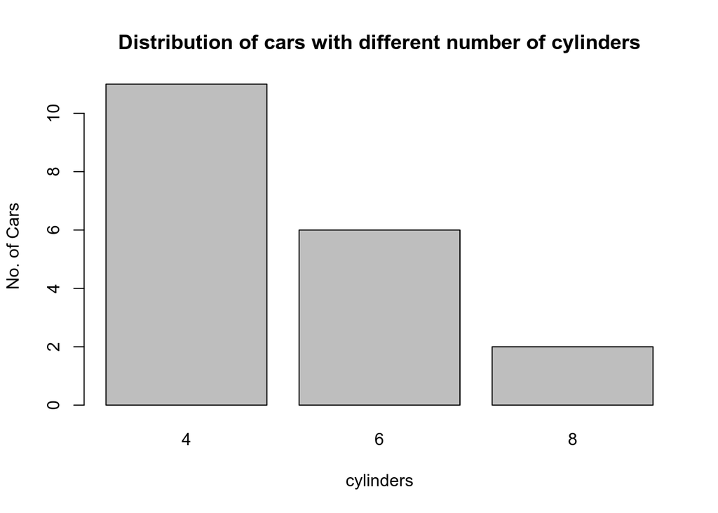

```r
# iii. make a bar plot to show how many cars are there with
#      different cyl above mpg 18

# Ref: Stackoverflow: all names in x-axis barplot https://t.ly/dxdWw
df.cyl.gt18 <- subset(df, mpg > 18, select=c(cyl))
t <- table(df.cyl.gt18)
names(dimnames(t)) <- NULL

barplot(t, xlab = "cylinders", ylab = "No. of Cars",
        main = "Distribution of cars with different number of cylinders")
```

```r
# iv. rank the cars (only names) in decreasing order of wt only till
#     wt = 3

row.names(subset(df[order(df$wt, decreasing = T), ], wt >= 3))
```

```
##  [1] "Lincoln Continental" "Chrysler Imperial"   "Cadillac Fleetwood"
##  [4] "Merc 450SE"          "Pontiac Firebird"    "Camaro Z28"
##  [7] "Merc 450SLC"         "Merc 450SL"          "Duster 360"
## [10] "Maserati Bora"       "Dodge Challenger"    "Valiant"
## [13] "Hornet Sportabout"   "Merc 280"            "Merc 280C"
## [16] "AMC Javelin"         "Hornet 4 Drive"      "Merc 240D"
## [19] "Ford Pantera L"      "Merc 230"
```

3. PlantGrowth dataset

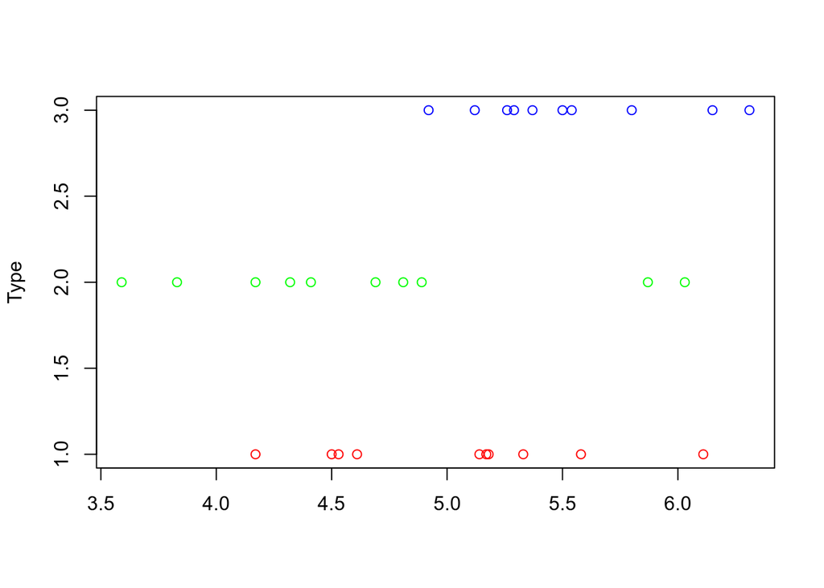

```r
# Q3
df <- PlantGrowth
df$group <- as.factor(df$group)
cols <- c("red", "green", "blue")[as.factor(df$group)]
plot(df$weight, df$group, col = cols, ylab = "Type", xlab = "")
```

```r
# Q4
# i. Load practice.txt in R into a data frame with two columns as
#    A and B from the file.

# Check first 5 lines to find a pattern
# They seem to be : separated
f <- "practice.txt"
for (l in readLines(f, n = 5)){
  cat(l, "\n")
}
```

```
## "A":"B"
## "1":-0.113715155050159:1.07818566296367
## "2":-0.049555906560272:-1.42175691829371
## "3":0.658047769684345:-1.59196414667602
## "4":-0.292051373049617:2.01125217605002
```

```r
df <- read.table(f, sep = ":")
head(df)
```

|  | A | B |
| --- | --- | --- |
| 1 | -0.11371516 | 1.078186 |
| 2 | -0.04955591 | -1.421757 |
| 3 | 0.65804777 | -1.591964 |
| 4 | -0.29205137 | 2.011252 |
| 5 | 0.60971928 | 1.101068 |
| 6 | -0.57043237 | -1.182669 |

```r
# ii. Compute the mean row wise and add as column
res <- cbind(df, rowMeans(df))
colnames(res)[ncol(res)] <- "rowmean"
```

```r
# iii. Compute the mean column wise and add as row
res <- rbind(res, colMeans(res))
rownames(res)[nrow(res)] <- "colmean"
```

This is how our result looks like

```r
res
```

|  | A | B | rowmean |
| --- | --- | --- | --- |
| 1 | -0.1137151551 | 1.0781856630 | 0.4822352540 |
| 2 | -0.0495559066 | -1.4217569183 | -0.7356564124 |
| 3 | 0.6580477697 | -1.5919641467 | -0.4669581885 |
| 4 | -0.2920513730 | 2.0112521761 | 0.8596004015 |
| 5 | 0.6097192797 | 1.1010682270 | 0.8553937533 |
| 6 | -0.5704323687 | -1.1826694980 | -0.8765509333 |
| 7 | -0.0602251166 | -0.8329866803 | -0.4466058984 |
| 8 | -0.4867400443 | -2.3604101564 | -1.4235751004 |
| 9 | -0.9416855401 | -0.7422737006 | -0.8419796204 |
| 10 | 0.8688243036 | -1.6539865906 | -0.3925811435 |

[output cut: 991 more lines]

```r
# iv. Save the modified data frame as csv file
ofile <- "practice_output.txt"
write.csv(res, ofile)
```